# Tarea13_AlejandroBarrantes

Alejandro Barrantes Castro

2023-06-15

# Funciones generales

```r
plotROC <- function(prediccion, real, adicionar = FALSE, color = "red") {
  pred <- ROCR::prediction(prediccion, real)
  perf <- ROCR::performance(pred, "tpr", "fpr")
  plot(perf, col = color, add = adicionar, main = "Curva ROC")
  segments(0, 0, 1, 1, col='black')
  grid()
}

calculaAreaROC <- function(prediccion, real) {
  pred <- ROCR::prediction(prediccion, real)
  perf <- ROCR::performance(pred, "auc")
  auc <- as.numeric(perf@y.values)
  return(auc)
}

precision<-function(clase){
  function(mc){
    indices=general.indexes(mc=mc)
    indices$category.accuracy[clase]
  }
}

precision.global<-function(x) sum(diag(x))/sum(x)

error.global <- function(x) 1 - sum(diag(x))/sum(x)
```

# Ejercicio #1

## Lectura

```r
setwd("~/ALEJANDRO/1er Ciclo 2023/Mineria de Datos/Tarea 13/Datos Clase y Tareas")
Datos <- read.csv("Tumores.csv", header=TRUE, sep=',',dec='.',stringsAsFactors = T)
enteros <- sapply(Datos, is.integer)
Datos[enteros] <- lapply(Datos[enteros], as.factor)

Datos$tipo <- factor(Datos$tipo)
Datos <- subset(Datos, select = -1)

set.seed(123) # Fijamos la semilla para reproducibilidad
indice <- createDataPartition(y = Datos$tipo, p = 0.25, list = FALSE)
ttesting <- Datos[indice, ]
ttraining <- Datos[-indice, ]
```

## 1.1

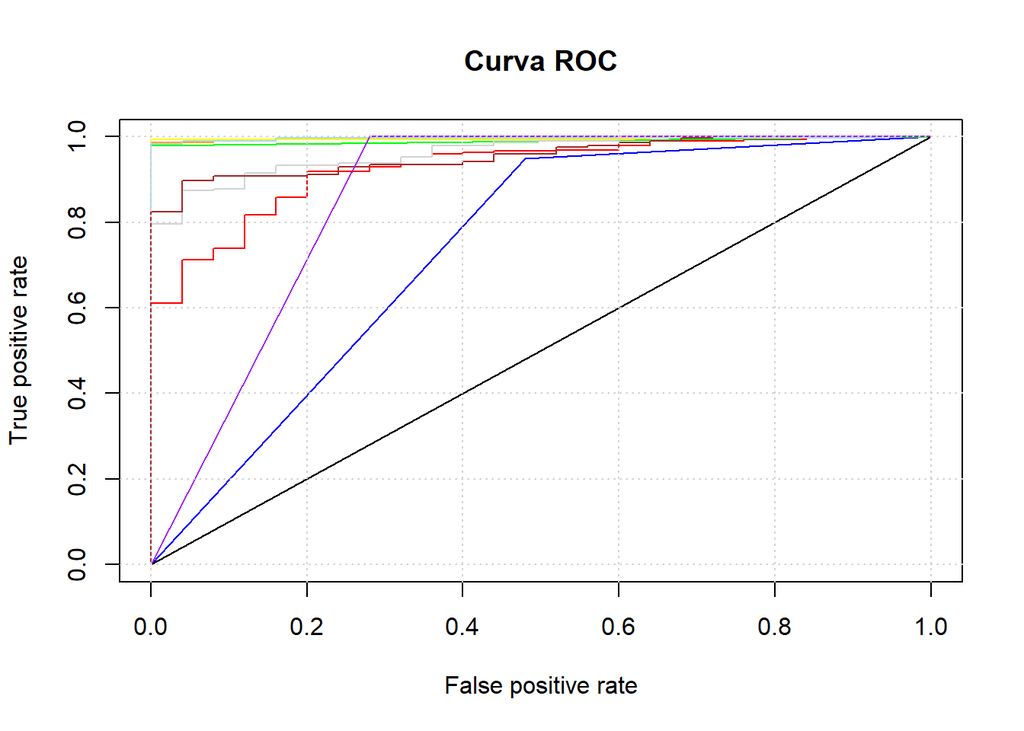

```r
tam <- floor(sqrt(nrow(Datos)))

#====================================
#svm
modelo <- train.svm(tipo ~ ., data = ttraining)
prediccion <- predict(modelo, ttesting, type = "prob")

Score <- prediccion$prediction[,2]
Clase <- ttesting$tipo
# Genera el gráfico
plotROC(Score,Clase)

#calcula el area de la curva
svm_area <- calculaAreaROC(Score, Clase)



#====================================
#knn
modelo <- train.knn(tipo ~ ., data = ttraining, kmax = tam)
prediccion <- predict(modelo, ttesting, type = "prob")


Score <- prediccion$prediction[,2]
Clase <- ttesting$tipo
# Genera el gráfico
plotROC(Score,Clase, adicionar=TRUE, color = "blue")

#calcula el area de la curva
knn_area <- calculaAreaROC(Score, Clase)

#====================================
#arboles
modelo <- train.rpart(tipo ~ ., data = ttraining)
prediccion <- predict(modelo, ttesting, type = "prob")


Score <- prediccion$prediction[,2]
Clase <- ttesting$tipo
# Genera el gráfico
plotROC(Score,Clase, adicionar=TRUE, color = "green")

#calcula el area de la curva
rpart_area <- calculaAreaROC(Score, Clase)

#====================================
#bosques
modelo <- train.randomForest(tipo ~ ., data = ttraining)
prediccion <- predict(modelo, ttesting, type = "prob")


Score <- prediccion$prediction[,2]
Clase <- ttesting$tipo
# Genera el gráfico
plotROC(Score,Clase, adicionar=TRUE, color = "yellow")

#calcula el area de la curva
randomForest_area <- calculaAreaROC(Score, Clase)

#====================================
#potenciacion
modelo <- train.ada(tipo ~ ., data = ttraining)
prediccion <- predict(modelo, ttesting, type = "prob")


Score <- prediccion$prediction[,2]
Clase <- ttesting$tipo
# Genera el gráfico
plotROC(Score,Clase, adicionar=TRUE, color = "orange")

#calcula el area de la curva
ada_area <- calculaAreaROC(Score, Clase)

# #====================================
#xgboost
modelo <- train.xgboost(tipo ~ ., data = ttraining, nrounds = 500,
                        print_every_n = 1000, maximize = F , eval_metric = "error")
prediccion <- predict(modelo, ttesting, type = "prob")


Score <- prediccion$prediction[,2]
Clase <- ttesting$tipo
# Genera el gráfico
plotROC(Score,Clase, adicionar=TRUE, color = "lightblue")

#calcula el area de la curva
xgboost_area <- calculaAreaROC(Score, Clase)

#====================================
#lda
modelo <- train.lda(tipo ~ ., data = ttraining)
prediccion <- predict(modelo, ttesting, type = "prob")


Score <- prediccion$prediction[,2]
Clase <- ttesting$tipo
# Genera el gráfico
plotROC(Score,Clase, adicionar=TRUE, color = "lightgray")

#calcula el area de la curva
lda_area <- calculaAreaROC(Score, Clase)

#====================================
#bayes
modelo <- train.bayes(tipo ~ ., data = ttraining)
prediccion <- predict(modelo, ttesting, type = "prob")


Score <- prediccion$prediction[,2]
Clase <- ttesting$tipo
# Genera el gráfico
plotROC(Score,Clase, adicionar=TRUE, color = "brown")

#calcula el area de la curva
bayes_area <- calculaAreaROC(Score, Clase)


#====================================
#nnet
modelo <- train.nnet(tipo ~ ., data = ttraining, size = 4, maxit = 1000, MaxNWts = 400, trace = FALSE)
prediccion <- predict(modelo, ttesting, type = "prob")


Score <- prediccion$prediction[,2]
Clase <- ttesting$tipo
# Genera el gráfico
plotROC(Score,Clase, adicionar=TRUE, color = "purple")
```

```r
#calcula el area de la curva
nnet_area <- calculaAreaROC(Score, Clase)
```

El mejor hasta el momento parecen ser mejores bosques, el cual es la curva que esta en color amarillo o ADA, la cual esta en color anaranjado, esta es muy parecida a la curva de bosques, por lo cual cuesta observarla bien, sin embargo se encuentra en algunos momentos por encima de bosques.

## 1.2

```r
resultados <- data.frame(Modelo = c("SVM", "KNN", "RPART", "RFOREST","ADA", "XGBOOST",
                                    "LDA","BAYES", "NNET"),
                         AREA = c(svm_area, knn_area,rpart_area, randomForest_area,
                                     ada_area,xgboost_area,lda_area,bayes_area,nnet_area))

#Saca el mejor modelo, es decir, el modelo con mas area sobre la linea, o la curva con mas area

mejor_modelo <- resultados[which.max(resultados$AREA),]

mejor_modelo
```

```
##   Modelo      AREA
## 5    ADA 0.9968814
```

Como podemos observar, bajo este proceso, el mejor metodo es el metodo ADA, ya que es el que tiene una mayor area en la curva, es decir, tiene mejores resultados en la curva que los demas metodos.

# Ejercicio #2

## 2.1

| Punto 1 | Umbral = T = 1 | Tasa FP=0 | Tasa TP=0 |
| --- | --- | --- | --- |
| MC |  | *Pred* | *Pred* |
|  | **Clase** | **0** | **1** |
| *Real* | **0** | 6 | 0 |
| *Real* | **1** | 4 | 0 |

[output not shown]

[output not shown]

[output not shown]

[output not shown]

[output not shown]

[output not shown]

[output not shown]

[output not shown]

[output not shown]

[output not shown]

[output not shown]

[output not shown]

[output not shown]

[output not shown]

[output not shown]

[output not shown]

| Punto 18 | Umbral = T = 0.15 | Tasa FP=0.67 | Tasa TP=0.75 |
| --- | --- | --- | --- |
| MC |  | *Pred* | *Pred* |
|  | **Clase** | **0** | **1** |
| *Real* | **0** | 2 | 4 |
| *Real* | **1** | 1 | 3 |

| Punto 19 | Umbral = T = 0.10 | Tasa FP=0.67 | Tasa TP=1 |
| --- | --- | --- | --- |
| MC |  | *Pred* | *Pred* |
|  | **Clase** | **0** | **1** |
| *Real* | **0** | 2 | 4 |
| *Real* | **1** | 0 | 4 |

| Punto 20 | Umbral = T = 0.05 | Tasa FP=0.83 | Tasa TP=1 |
| --- | --- | --- | --- |
| MC |  | *Pred* | *Pred* |
|  | **Clase** | **0** | **1** |
| *Real* | **0** | 1 | 5 |
| *Real* | **1** | 0 | 4 |

## 2.2

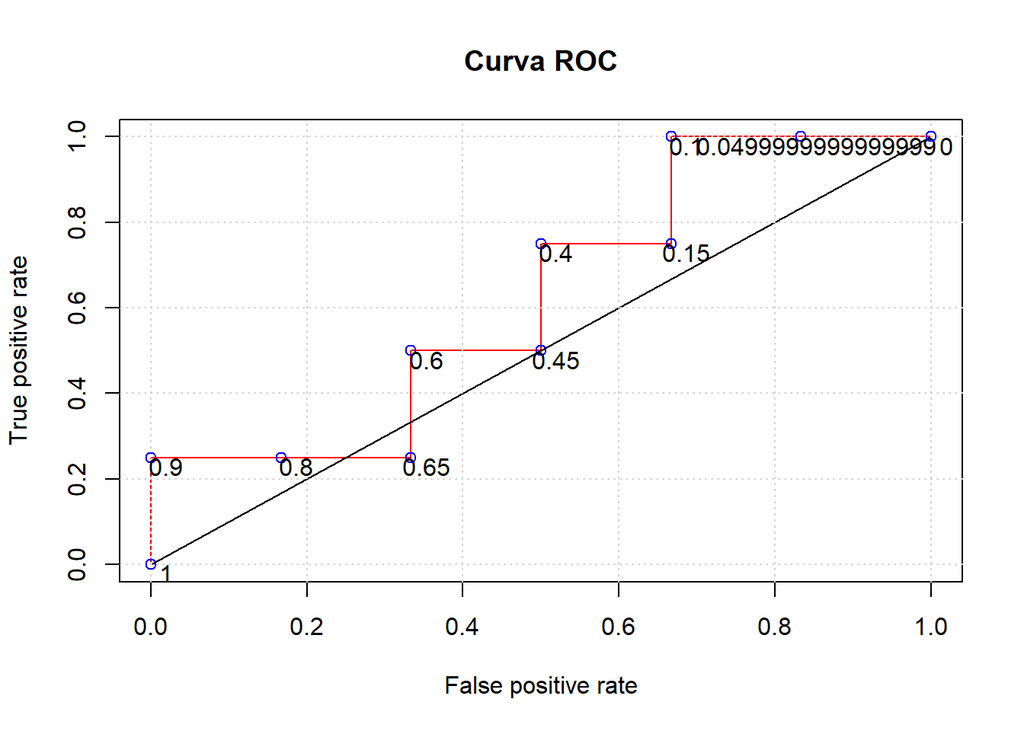

```
## Punto i =  1
## Umbral = T =  1
## MC =
##      Pred
## Clase 0 1
##     0 6 0
##     1 4 0
## Tasa FP =  0
## Tasa TP =  0
##
## Punto i =  2
## Umbral = T =  0.9
## MC =
##      Pred
## Clase 0 1
##     0 6 0
##     1 3 1
## Tasa FP =  0
## Tasa TP =  0.25
##
## Punto i =  3
## Umbral = T =  0.8
## MC =
##      Pred
## Clase 0 1
##     0 5 1
##     1 3 1
## Tasa FP =  0.17
## Tasa TP =  0.25
##
## Punto i =  4
## Umbral = T =  0.65
## MC =
##      Pred
## Clase 0 1
##     0 4 2
##     1 3 1
## Tasa FP =  0.33
## Tasa TP =  0.25
##
```

[output cut: 54 more lines]

```
## Clase 0 1
##     0 1 5
##     1 0 4
## Tasa FP =  0.83
## Tasa TP =  1
##
## Punto i =  11
## Umbral = T =  0
## MC =
##      Pred
## Clase 0 1
##     0 0 6
##     1 0 4
## Tasa FP =  1
## Tasa TP =  1
```

```r
Clase <- c(1,0,0,1,0,0,1,0,0,1)
Score <- c(0.61, 0.06,0.80, 0.11, 0.66, 0.46, 0.40, 0.19, 0.00, 0.91)

# Graficamos ROC con funciones de paquete ROCR
plotROC(Score, Clase)

# Graficamos puntos con algoritmo
i <- 1  # Contador
FP_r <- -1  # Para que entre al condicional en la primera iteración
TP_r <- -1  # Para que entre al condicional en la primera iteración

for(Umbral in seq(1, 0, by = -0.05)) {

  Prediccion <- ifelse(Score >= Umbral, 1, 0)

  MC <- table(Clase, Pred = factor(Prediccion, levels = c(0, 1)))

  # Condicional para no imprimir puntos repetidos
  if(FP_r != MC[1, 2] / sum(MC[1, ]) | TP_r != MC[2, 2] / sum(MC[2, ])) {

    FP_r <- MC[1, 2] / sum(MC[1, ])  # Tasa de Falsos Positivos
    TP_r <- MC[2, 2] / sum(MC[2, ])  # Tasa de Verdaderos Positivos

    # Graficamos punto
    points(FP_r, TP_r, col = "blue")
    text(FP_r + 0.02, TP_r - 0.02, Umbral)

    # Imprimimos resultados
    cat("Punto i = ", i, "\n")
    cat("Umbral = T = ", Umbral, "\n")
    cat("MC = \n")
    print(MC)
    cat("Tasa FP = ", round(FP_r, 2), "\n")
    cat("Tasa TP = ", round(TP_r, 2), "\n")
    cat("\n")

    i <- i + 1  # Aumentamos contador

  }

}
```

## 2.3

```r
# =======================
# Punto:  1
# 2.7 > T y class= 1 => TP= 1
# FP= 12
# FP= 10
# FP/10= 1.2
# TP/10= 1
# Punto: ( 2 , 2.5 )
#
# =======================
# Punto:  2
# 2.8 > T y class= 0 => FP= 1
# FP= 13
# FP= 10
# FP/10= 1.3
# TP/10= 1
# Punto: ( 2.1667 , 2.5 )
#
# =======================
# Punto:  3
# 2.9 > T y class= 0 => FP= 2
# FP= 14
# FP= 10
# FP/10= 1.4
# TP/10= 1
# Punto: ( 2.3333 , 2.5 )
#
# =======================
# Punto:  4
# 3 > T y class= 1 => TP= 2
# FP= 14
# FP= 11
# FP/10= 1.4
# TP/10= 1.1
# Punto: ( 2.333 , 2.75 )
#
# =======================
# Punto:  5
# 3.1 > T y class= 0 => FP= 3
# FP= 15
# FP= 11
# FP/10= 1.5
# TP/10= 1.1
# Punto: ( 2.5 , 2.75 )
#
# =======================
# Punto:  6
# 3.2 > T y class= 1 => TP= 3
# FP= 15
# FP= 12
# FP/10= 1.5
# TP/10= 1.2
# Punto: ( 2.5 , 3 )
#
# =======================
# Punto:  7
# 3.3 > T y class= 0 => FP= 4
# FP= 16
# FP= 12
# FP/10= 1.6
# TP/10= 1.2
# Punto: ( 2.667 , 3 )
#
# =======================
# Punto:  8
# 3.4 > T y class= 1 => TP= 4
# FP= 16
# FP= 13
# FP/10= 1.6
# TP/10= 1.3
# Punto: ( 2.6667 , 3.25 )
#
# =======================
# Punto:  9
# 3.5 > T y class= 0 => FP= 5
# FP= 17
# FP= 13
# FP/10= 1.7
# TP/10= 1.3
# Punto: ( 2.8333 , 3.25 )
#
# =======================
# Punto:  10
# 3.6 > T y class= 0 => FP= 6
# FP= 18
# FP= 13
# FP/10= 1.8
# TP/10= 1.3
# Punto: ( 3 , 3.25 )
```

## 2.4

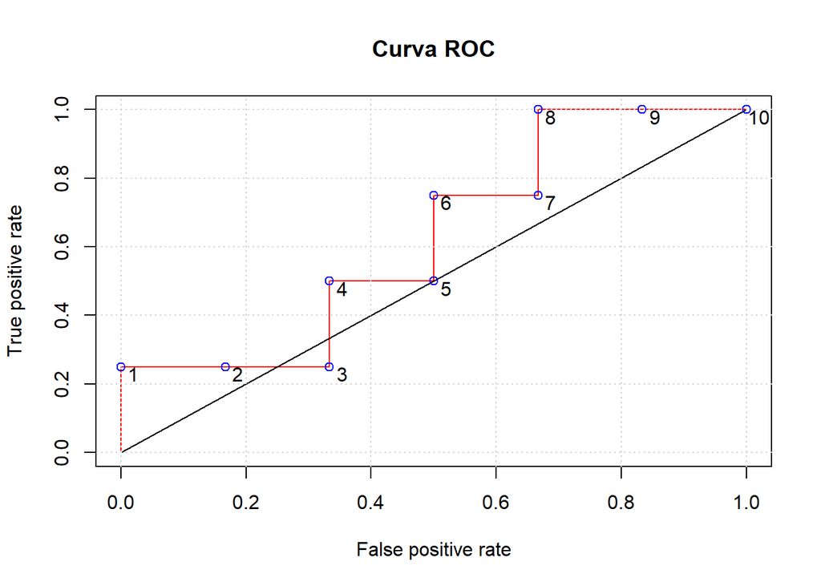

```r
Clase <- c(1,0,0,1,0,1,0,1,0,0)
Score <- c(0.91,0.80, 0.66, 0.61, 0.46, 0.40, 0.19, 0.11, 0.06, 0.00)

plotROC(Score, Clase)

Umbral<--0.5
Paso <- 0.1

N <- 6 # ceros
P <- 4 # unos

TP <- 0
FP <- 0

for(i in 1:10) {

  if(Score[i] > Umbral)
    if(Clase[i] == 1)
      TP <- TP + 1
  else
    FP <- FP + 1
  else
    if(Clase[i] == 0)
      FP <- FP + 1
    else
      TP <- TP + 1

    # Graficamos punto
    points(FP / N, TP / P, col = "blue")
    text(FP / N + 0.02, TP / P - 0.02, i)

    Umbral <- Umbral + Paso

}
```

# Ejercicio #3

### Lectura de Datos

```r
setwd("~/ALEJANDRO/1er Ciclo 2023/Mineria de Datos/Tarea 13/Datos Clase y Tareas")
Datos <- read.csv("SAheart.csv", header=TRUE, sep=';',dec='.',stringsAsFactors = T)

# set.seed(123) # Fijamos la semilla para reproducibilidad
indice <- createDataPartition(y = Datos$chd, p = 0.25, list = FALSE)
ttesting <- Datos[indice, ]
ttraining <- Datos[-indice, ]
```

## 3.1

```r
probabilidades <- seq(1, 0, by = -0.05)
resultados <- data.frame(matrix(0, nrow = 9, ncol = length(probabilidades) + 1))

colnames(resultados) <- c("Modelo", as.character(probabilidades))

resultados$Modelo <- c("SVM", "KNN", "RPART", "RFOREST", "ADA", "XGBOOST", "LDA", "BAYES", "NNET")


#====================================
#svm
modelo <- train.svm(chd ~ ., data = ttraining)
prediccion <- predict(modelo, ttesting, type = "prob")

Score <- prediccion$prediction[,2]
Clase <- ttesting$chd

# Calculo de probabilidades
for(Corte in seq(1, 0, by = -0.05)) {

  Prediccion <- ifelse(Score >= Corte, "Si", "No")
  MC <- table(Clase, Pred = factor(Prediccion, levels = c("No", "Si")))
  indices<-general.indexes(mc=MC)

  negativos<-round(indices$category.accuracy[1], digits = 4)
  positivos<-round(indices$category.accuracy[2], digits = 4)

  resultados[1, which(colnames(resultados) == (Corte))] <- paste("No: ",negativos,"Si: ", positivos)
}


#====================================
#knn
modelo <- train.knn(chd ~ ., data = ttraining, kmax = tam)
prediccion <- predict(modelo, ttesting, type = "prob")


Score <- prediccion$prediction[,2]
Clase <- ttesting$chd

# Calculo de probabilidades
for(Corte in seq(1, 0, by = -0.05)) {

  Prediccion <- ifelse(Score >= Corte, "Si", "No")
  MC <- table(Clase, Pred = factor(Prediccion, levels = c("No", "Si")))
  indices<-general.indexes(mc=MC)

  negativos<-round(indices$category.accuracy[1], digits = 4)
  positivos<-round(indices$category.accuracy[2], digits = 4)

  resultados[2, which(colnames(resultados) == (Corte))] <- paste("No: ",negativos,"Si: ", positivos)
}

#====================================
#arboles
modelo <- train.rpart(chd ~ ., data = ttraining)
prediccion <- predict(modelo, ttesting, type = "prob")


Score <- prediccion$prediction[,2]
Clase <- ttesting$chd

# Calculo de probabilidades
for(Corte in seq(1, 0, by = -0.05)) {

  Prediccion <- ifelse(Score >= Corte, "Si", "No")
  MC <- table(Clase, Pred = factor(Prediccion, levels = c("No", "Si")))
  indices<-general.indexes(mc=MC)

  negativos<-round(indices$category.accuracy[1], digits = 4)
  positivos<-round(indices$category.accuracy[2], digits = 4)

  resultados[3, which(colnames(resultados) == (Corte))] <- paste("No: ",negativos,"Si: ", positivos)
}

#====================================
#bosques
modelo <- train.randomForest(chd ~ ., data = ttraining)
prediccion <- predict(modelo, ttesting, type = "prob")


Score <- prediccion$prediction[,2]
Clase <- ttesting$chd

# Calculo de probabilidades
for(Corte in seq(1, 0, by = -0.05)) {

  Prediccion <- ifelse(Score >= Corte, "Si", "No")
  MC <- table(Clase, Pred = factor(Prediccion, levels = c("No", "Si")))
  indices<-general.indexes(mc=MC)

  negativos<-round(indices$category.accuracy[1], digits = 4)
  positivos<-round(indices$category.accuracy[2], digits = 4)

  resultados[4, which(colnames(resultados) == (Corte))] <- paste("No: ",negativos,"Si: ", positivos)
}

#====================================
#potenciacion
modelo <- train.ada(chd ~ ., data = ttraining)
prediccion <- predict(modelo, ttesting, type = "prob")


Score <- prediccion$prediction[,2]
Clase <- ttesting$chd


# Calculo de probabilidades
for(Corte in seq(1, 0, by = -0.05)) {

  Prediccion <- ifelse(Score >= Corte, "Si", "No")
  MC <- table(Clase, Pred = factor(Prediccion, levels = c("No", "Si")))
  indices<-general.indexes(mc=MC)

  negativos<-round(indices$category.accuracy[1], digits = 4)
  positivos<-round(indices$category.accuracy[2], digits = 4)

  resultados[5, which(colnames(resultados) == (Corte))] <- paste("No: ",negativos,"Si: ", positivos)
}

# #====================================
# #xgboost
modelo <- train.xgboost(chd ~ ., data = ttraining, nrounds = 500,
                        print_every_n = 1000, maximize = F , eval_metric = "error")
prediccion <- predict(modelo, ttesting, type = "prob")


Score <- prediccion$prediction[,2]
Clase <- ttesting$chd


# Calculo de probabilidades
for(Corte in seq(1, 0, by = -0.05)) {

  Prediccion <- ifelse(Score >= Corte, "Si", "No")
  MC <- table(Clase, Pred = factor(Prediccion, levels = c("No", "Si")))
  indices<-general.indexes(mc=MC)

  negativos<-round(indices$category.accuracy[1], digits = 4)
  positivos<-round(indices$category.accuracy[2], digits = 4)

  resultados[6, which(colnames(resultados) == (Corte))] <- paste("No: ",negativos,"Si: ", positivos)
}

#====================================
#lda
modelo <- train.lda(chd ~ ., data = ttraining)
prediccion <- predict(modelo, ttesting, type = "prob")


Score <- prediccion$prediction[,2]
Clase <- ttesting$chd

# Calculo de probabilidades
for(Corte in seq(1, 0, by = -0.05)) {

  Prediccion <- ifelse(Score >= Corte, "Si", "No")
  MC <- table(Clase, Pred = factor(Prediccion, levels = c("No", "Si")))
  indices<-general.indexes(mc=MC)

  negativos<-round(indices$category.accuracy[1], digits = 4)
  positivos<-round(indices$category.accuracy[2], digits = 4)

  resultados[7, which(colnames(resultados) == (Corte))] <- paste("No: ",negativos,"Si: ", positivos)
}

#====================================
#bayes
modelo <- train.bayes(chd ~ ., data = ttraining)
prediccion <- predict(modelo, ttesting, type = "prob")


Score <- prediccion$prediction[,2]
Clase <- ttesting$chd

# Calculo de probabilidades
for(Corte in seq(1, 0, by = -0.05)) {

  Prediccion <- ifelse(Score >= Corte, "Si", "No")
  MC <- table(Clase, Pred = factor(Prediccion, levels = c("No", "Si")))
  indices<-general.indexes(mc=MC)

  negativos<-round(indices$category.accuracy[1], digits = 4)
  positivos<-round(indices$category.accuracy[2], digits = 4)

  resultados[8, which(colnames(resultados) == (Corte))] <- paste("No: ",negativos,"Si: ", positivos)
}

#====================================
#nnet
modelo <- train.nnet(chd ~ ., data = ttraining, size = 4, maxit = 1000, MaxNWts = 400, trace = FALSE)
prediccion <- predict(modelo, ttesting, type = "prob")


Score <- prediccion$prediction[,2]
Clase <- ttesting$chd

# Calculo de probabilidades
for(Corte in seq(1, 0, by = -0.05)) {

  Prediccion <- ifelse(Score >= Corte, "Si", "No")
  MC <- table(Clase, Pred = factor(Prediccion, levels = c("No", "Si")))
  indices<-general.indexes(mc=MC)

  negativos<-round(indices$category.accuracy[1], digits = 4)
  positivos<-round(indices$category.accuracy[2], digits = 4)

  resultados[9, which(colnames(resultados) == (Corte))] <- paste("No: ",negativos,"Si: ", positivos)
}

print(resultados)
```

```
##    Modelo                  1                   0.95                    0.9
## 1     SVM      No:  1 Si:  0          No:  1 Si:  0          No:  1 Si:  0
## 2     KNN      No:  1 Si:  0          No:  1 Si:  0          No:  1 Si:  0
## 3   RPART No:  0.9079 Si:  0     No:  0.9079 Si:  0     No:  0.9079 Si:  0
## 4 RFOREST      No:  1 Si:  0          No:  1 Si:  0          No:  1 Si:  0
## 5     ADA      No:  1 Si:  0          No:  1 Si:  0          No:  1 Si:  0
## 6 XGBOOST      No:  1 Si:  0 No:  0.8947 Si:  0.225 No:  0.8158 Si:  0.325
## 7     LDA      No:  1 Si:  0      No:  1 Si:  0.025      No:  1 Si:  0.025
## 8   BAYES      No:  1 Si:  0 No:  0.9342 Si:  0.325  No:  0.9211 Si:  0.35
## 9    NNET      No:  1 Si:  0          No:  1 Si:  0          No:  1 Si:  0
##                    0.85                    0.8                   0.75
## 1         No:  1 Si:  0          No:  1 Si:  0          No:  1 Si:  0
## 2         No:  1 Si:  0          No:  1 Si:  0     No:  0.9868 Si:  0
## 3    No:  0.9079 Si:  0 No:  0.8158 Si:  0.375 No:  0.8158 Si:  0.375
## 4         No:  1 Si:  0 No:  0.9868 Si:  0.025  No:  0.9737 Si:  0.05
```

[output cut: 55 more lines]

## 3.2

```r
peones <- parallel::detectCores()
clp <- makeCluster(peones, type = "SOCK")


ejecutar.prediccion <- function(datos, formula, muestra, metodo, ...) {
  ttesting <- datos[muestra, ]
  ttraining <- datos[-muestra, ]
  modelo <- do.call(metodo, list(formula, data = ttraining, ...))
  prediccion <- predict(modelo, ttesting, type = "class")
  MC <- confusion.matrix(ttesting, prediccion)
  return(MC)
}

# La siguiente función permite fijar parámetros específicos para cada método, lo cual es útil para usar otros parámetros que no sean los default.

ejecutar.prediccion.particular <- function(datos, formula, muestra, metodo) {
  if(metodo == "train.svm"){
    return(ejecutar.prediccion(datos, formula, muestra, metodo))}
  if(metodo == "train.knn"){
    return(ejecutar.prediccion(datos, formula, muestra, metodo,kernel="optimal", kmax = tam))}
  if(metodo == "train.bayes"){
    return(ejecutar.prediccion(datos, formula, muestra, metodo))}
  if(metodo == "train.rpart"){
    return(ejecutar.prediccion(datos, formula, muestra, metodo))}
  if(metodo == "train.randomForest"){
    return(ejecutar.prediccion(datos, formula, muestra, metodo, importance = TRUE))}
  if(metodo == "train.ada"){
    return(ejecutar.prediccion(datos, formula, muestra, metodo, iter = 500, type = "gentle"))}
  if(metodo == "train.nnet"){
    return(ejecutar.prediccion(datos, formula, muestra, metodo, size = 4, maxit = 1000, MaxNWts = 400, trace = FALSE))}
  if(metodo == "train.xgboost"){
    return(ejecutar.prediccion(datos, formula, muestra, metodo, nrounds = 500))}
  if(metodo == "train.glm"){
    return(ejecutar.prediccion(datos, formula, muestra, metodo))}
  if(metodo == "train.neuralnet"){
    return(ejecutar.prediccion(datos, formula, muestra, metodo, hidden = c(8,6,4), linear.output = FALSE))}
}

# Constructor del cluster
numero.filas <- nrow(Datos)
cantidad.validacion.cruzada <- 3
cantidad.grupos <- 10
metodos <- c("train.svm", "train.knn", "train.bayes", "train.rpart", "train.randomForest", "train.ada", "train.nnet",
             "train.xgboost", "train.neuralnet", "train.glm")

tam <- floor(sqrt(nrow(Datos)))
clusterExport(clp, "tam")

MCs.svm <- list()
MCs.knn <- list()
MCs.bayes <- list()
MCs.arbol <- list()
MCs.bosque <- list()
MCs.potenciacion <- list()
MCs.red <- list()
MCs.xgboost <- list()
MCs.red.neu <- list()
MCs.glm <- list()

# Exportamos paquetes a los procesadores
ignore <- clusterEvalQ(clp, {
  library(dplyr)
  library(traineR)

  return(NULL)
})

# Exportamos los datos y las funciones a los procesadores
clusterExport(clp, list("Datos", "ejecutar.prediccion", "ejecutar.prediccion.particular"))

tiempo.paralelo <- Sys.time()

# Validación cruzada 3 veces
for(i in 1:cantidad.validacion.cruzada) {
  grupos <- createFolds(1:numero.filas, cantidad.grupos)  # Crea los 10 grupos
  MC.svm <- matrix(c(0,0,0,0), nrow=2)
  MC.knn <- matrix(c(0,0,0,0), nrow=2)
  MC.bayes <- matrix(c(0,0,0,0), nrow=2)
  MC.arbol <- matrix(c(0,0,0,0), nrow=2)
  MC.bosque <- matrix(c(0,0,0,0), nrow=2)
  MC.potenciacion <- matrix(c(0,0,0,0), nrow=2)
  MC.red <- matrix(c(0,0,0,0), nrow=2)
  MC.xg  <- matrix(c(0,0,0,0), nrow=2)
  MC.red.neu <- matrix(c(0,0,0,0), nrow=2)
  MC.glm <- matrix(c(0,0,0,0), nrow=2)

  # Este ciclo es el que hace validación cruzada con 10 grupos
  for(k in 1:cantidad.grupos) {
    muestra <- grupos[[k]]  # Por ser una lista requiere de doble paréntesis
    # Exportamos la muestra a los procesadores
    clusterExport(clp, "muestra")

    resultado <- clusterApply(clp, metodos, function(metodo) {
     tryCatch({
        MC <- ejecutar.prediccion.particular(datos = Datos, formula = chd ~ ., muestra = muestra, metodo              = metodo)

        valores <- list(Tipo = metodo, Resultado = MC)
        return(valores)
      }, error = function(e) {
        return(list(Error = as.character(e)))
      })
    })

    for (j in seq_along(metodos)) {
      if (resultado[[j]][[1]] == "train.svm")
        MC.svm <- MC.svm + resultado[[j]][[2]]
      else if (resultado[[j]][[1]] == "train.knn")
        MC.knn <- MC.knn + resultado[[j]][[2]]
      else if (resultado[[j]][[1]] == "train.bayes")
        MC.bayes <- MC.bayes + resultado[[j]][[2]]
      else if (resultado[[j]][[1]] == "train.rpart")
        MC.arbol <- MC.arbol + resultado[[j]][[2]]
      else if (resultado[[j]][[1]] == "train.randomForest")
        MC.bosque <- MC.bosque + resultado[[j]][[2]]
      else if (resultado[[j]][[1]] == "train.ada")
        MC.potenciacion <- MC.potenciacion + resultado[[j]][[2]]
      else if (resultado[[j]][[1]] == "train.nnet")
        MC.red <- MC.red + resultado[[j]][[2]]
      else if (resultado[[j]][[1]] == "train.xgboost")
        MC.xg <- MC.xg + resultado[[j]][[2]]
      else if (resultado[[j]][[1]] == "train.neuralnet")
        MC.red.neu <- MC.red.neu + resultado[[j]][[2]]
      else if (resultado[[j]][[1]] == "train.glm")
        MC.glm <- MC.glm + resultado[[j]][[2]]
    }

  }
  MCs.svm[[i]] <- MC.svm
  MCs.knn[[i]] <- MC.knn
  MCs.bayes[[i]] <- MC.bayes
  MCs.arbol[[i]] <- MC.arbol
  MCs.bosque[[i]] <- MC.bosque
  MCs.potenciacion[[i]] <- MC.potenciacion
  MCs.red[[i]] <- MC.red
  MCs.xgboost[[i]]<- MC.xg
  MCs.red.neu[[i]] <- MC.red.neu
  MCs.glm[[i]] <- MC.glm
}

stopCluster(clp)
```

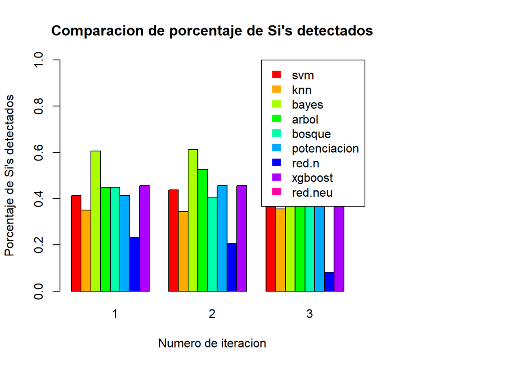

```r
# GRAFICACION Si's
resultados <- data.frame("svm"     = sapply(MCs.svm,precision("Si")),
                         "knn"     =sapply(MCs.knn,precision("Si")) ,
                         "bayes" = sapply(MCs.bayes,precision("Si")),
                         "arbol"     = sapply(MCs.arbol,precision("Si")),
                         "bosque"     = sapply(MCs.bosque,precision("Si")),
                         "potenciacion" = sapply(MCs.potenciacion,precision("Si")),
                         "red.n"     = sapply(MCs.red,precision("Si")),
                         "xgboost"     =sapply(MCs.xgboost,precision("Si")) ,
                         "red.neu" = sapply(MCs.red.neu,precision("Si"))) # Preparamos los datos

par(oma = c(0, 0, 0, 8))  # Hace espacio para la leyenda

# Crear el gráfico de barras
barplot(t(resultados),beside = TRUE,ylim = c(0, 1),names.arg = 1:nrow(resultados),xlab ="Numero de iteracion",ylab = "Porcentaje de Si's detectados",main = "Comparacion de porcentaje de Si's detectados",col = rainbow(ncol(resultados)))

# Agregar la leyenda
legend("topright",legend = colnames(resultados),fill = rainbow(ncol(resultados)),border = NA)
```

Segun el grafico mostrado, en cada iteracion sobresale el metodo bayes, ya que es el que encuentra o predice la mayor de cantidad de Si’s, refiriendose a que si se encuentra la variable ‘chd’ en el sistema del individuo. Por tanto, se puede deducir que este es el mejor metodo a la hora de ejecucion.

## 3.3

Claramente, a como se ha venido trabajando, y sabiendo todo lo que hemos aprendido en esta tarea y tema, se podria buscar cual es el corte de probabilidad mas eficiente para la prediccion de la variable ‘chd’ en este conjunto de datos. Asi nos aseguramos de que detecte la mayor cantidad de Si’s, la variable que nos interesa, pero tambien detecte la mayor cantidad de No’s al mismo tiempo. Y asi estar seguros de que se esta trabajando correctamente y de que la prediccion es lo mas precisa posible.